# cellmig: quantifying cell migration with hierarchical Bayesian models

Simo Kitanovski (simo.kitanovski@uni-due.de)

14 Mai 2025

# 1 Background

```r
library(cellmig)
library(ggplot2)
library(ggforce)
library(patchwork)
library(skimr)
ggplot2::theme_set(new = theme_bw(base_size = 10))
```

# 2 Data (raw)

This is how a typical cell migration data looks like $\rightarrow$ a table.

Each rows is a cell with the following features:

- well = unique well ID (w1, w2, w3, etc.).
- plate = unique plate ID (p1, p2, p3, etc.). A plate contains multiple wells.
- compound = compound name (c1, c2, c3, etc.)
- treatment dose (0, 1, 5, 10, low, mid, high, etc.)
- v = Observed cell migration speed (numeric)
- offset = binary (0 or 1). Indicates whether a treatment should be used for batch correction across plates. By default offset = 0 (no correction). Set to 1 for specific treatment groups (compound x dose) used as offsets. Ensure that this treatment group appears on each plate.

```r
data("d", package = "cellmig")
d$offset <- 0
knitr::kable(d[1:10,], row.names = F, digits = 2)
```

| well | plate | compound | dose | v | offset |
| --- | --- | --- | --- | --- | --- |
| 1 | 1 | C1 | D1 | 3.59 | 0 |
| 1 | 1 | C1 | D1 | 6.56 | 0 |
| 1 | 1 | C1 | D1 | 0.73 | 0 |
| 1 | 1 | C1 | D1 | 5.30 | 0 |
| 1 | 1 | C1 | D1 | 4.96 | 0 |
| 1 | 1 | C1 | D1 | 1.47 | 0 |
| 1 | 1 | C1 | D1 | 6.87 | 0 |
| 1 | 1 | C1 | D1 | 8.71 | 0 |
| 1 | 1 | C1 | D1 | 6.09 | 0 |
| 1 | 1 | C1 | D1 | 7.42 | 0 |

These are the unique plate, well and group IDs.

```r
apply(X = d[,2:ncol(d)], MARGIN = 2, FUN = unique)
```

[output not shown]

[output cut: 1638 more lines]

[output not shown]

In this vignette we will use simulated data from:

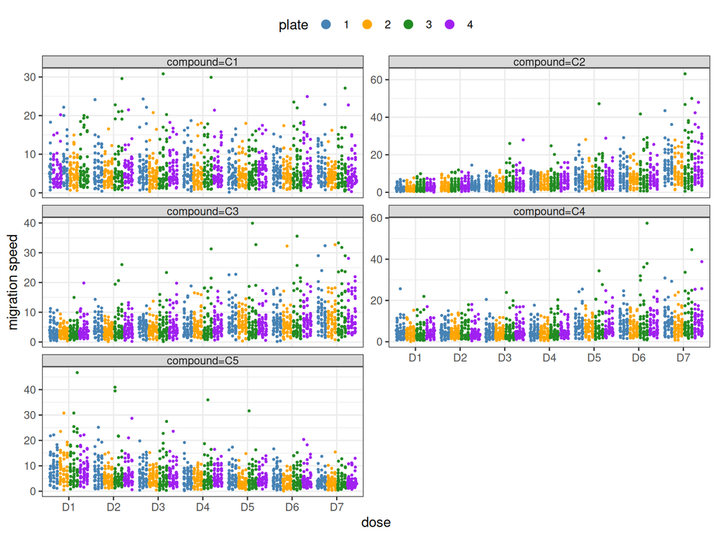

```r
ggplot(data = d)+
  facet_wrap(facets = ~paste0("compound=", compound), scales = "free_y", ncol = 2)+
  geom_sina(aes(x = as.factor(dose), col = plate, y = v, group = well), size = 0.5)+
  theme_bw()+
  theme(legend.position = "top",
        strip.text.x = element_text(margin = margin(0.03,0,0.03,0, "cm")))+
  xlab(label = "dose")+
  ylab(label = "migration speed")+
  scale_color_manual(values = c("steelblue", "orange", "forestgreen", "purple"))+
  guides(color = guide_legend(override.aes = list(size = 3)))+
  guides(shape = guide_legend(override.aes = list(size = 3)))
```

# 3 We can also show the **mean migration** per well (across all 20 cells each well)

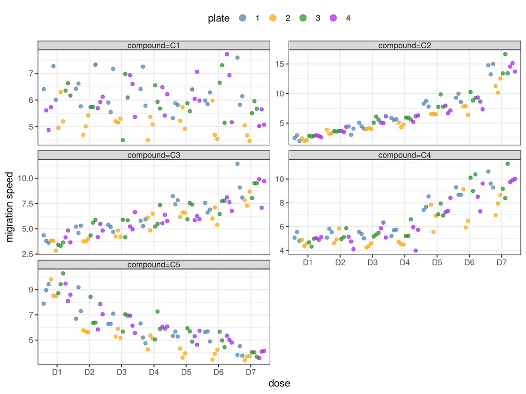

```r
dm <- aggregate(v~well+plate+compound+dose, data = d, FUN = mean)
ggplot(data = dm)+
  facet_wrap(facets = ~paste0("compound=", compound), scales = "free_y", ncol = 2)+
  geom_sina(aes(x = as.factor(dose), col = plate, y = v, group = well),
            size = 1.5, alpha = 0.7)+
  theme_bw()+
  theme(legend.position = "top",
        strip.text.x = element_text(margin = margin(0.03,0,0.03,0, "cm")))+
  xlab(label = "dose")+
  ylab(label = "migration speed")+
  scale_color_manual(values = c("steelblue", "orange", "forestgreen", "purple"))+
  guides(color = guide_legend(override.aes = list(size = 3)))+
  guides(shape = guide_legend(override.aes = list(size = 3)))
```

# 4 Model fitting

```r
o <- cellmig(x = d,
             control = list(mcmc_warmup = 300,
                            mcmc_steps = 1000,
                            mcmc_chains = 3,
                            mcmc_cores = 3,
                            mcmc_algorithm = "NUTS",
                            adapt_delta = 0.8,
                            max_treedepth = 10))
```

# 5 What are the overall effects of compounds and doses on cell migration?

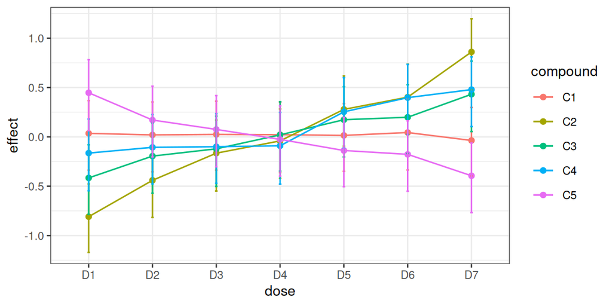

```r
ggplot(data = o$posteriors$mu_group)+
  geom_line(aes(x = dose, y = mean, col = compound, group = compound))+
  geom_point(aes(x = dose, y = mean, col = compound))+
  geom_errorbar(aes(x = dose, y = mean, ymin = X2.5., ymax = X97.5.,
                    col = compound), width = 0.04)+
  ylab(label = "effect")
```

# 6 Compare the dose-response `profiles` for different compounds

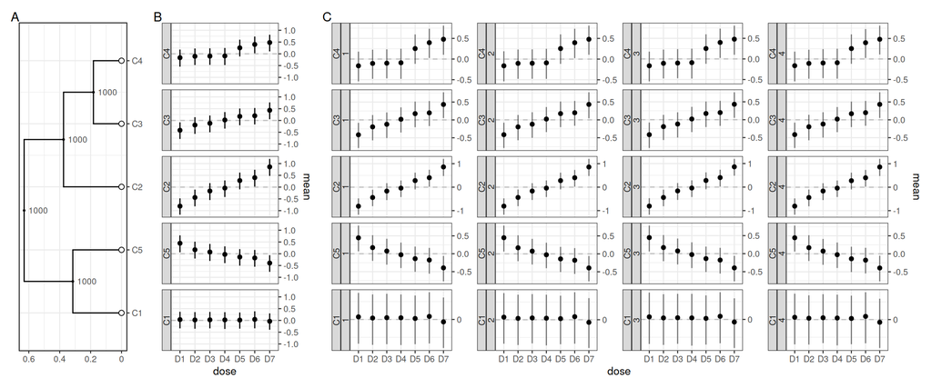

```r
get_dose_response_profile(x = o)+
  patchwork::plot_layout(widths = c(1, 1, 5))
```

# 7 Compare the treatment group `profiles`

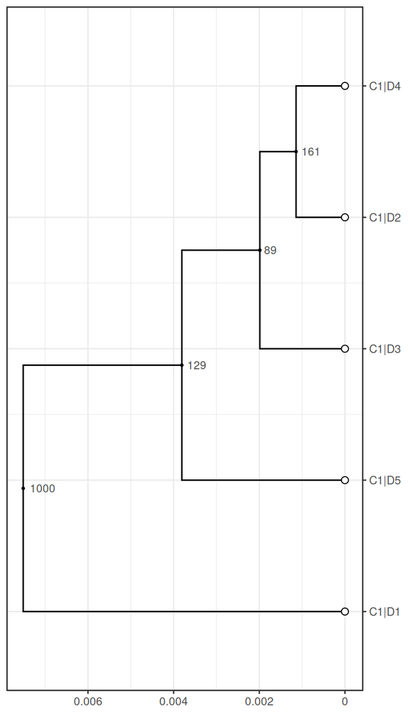

```r
get_treatment_profile(x = o,
                      hc_link = "average",
                      hc_dist = "euclidean",
                      select_gs = get_groups(o)$group[1:5],
                      B = 1000)
```

# 8 Compare the effects between treatment group

## 8.1 Pairwise dot-plot comparison $\rightarrow$ x minus y axis

- x/y-axis treatment groups (combinations of compounds and doses)
- $\rho$: Difference between treatment groups at y-x axis.
- $\pi$: probability of observing either a completely positive or negative $\rho$

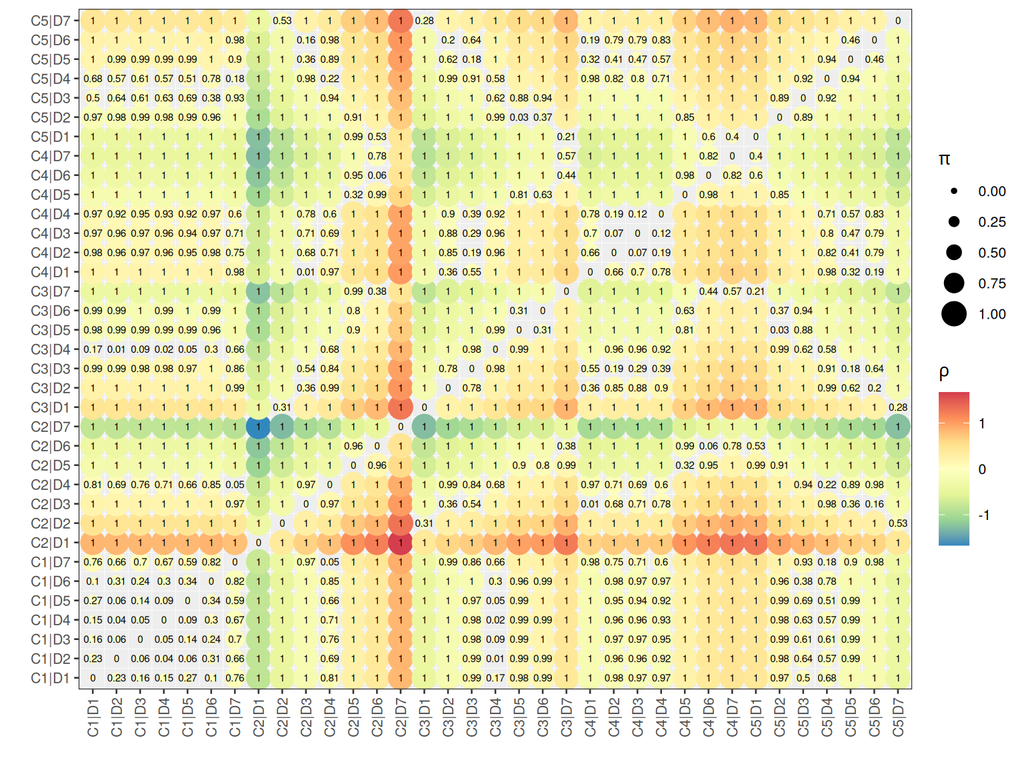

```r
u <- get_pairs(x = o)
u$plot
```

## 8.2 Violin plot based comparison

- from_groups: vector of treatment groups to consider (combinations of compounds and doses)
- to_group: target treatment group
- violins show the posterior distributions of the differences ($\rho$: each element from `from_groups` vs. `to_group`).
- label: probability, $\pi$, of observing completely positive or negative $\rho$

```r
get_groups(x = o)
```

```
FALSE    group_id group compound dose
FALSE 1         1 C1|D1       C1   D1
FALSE 2         2 C1|D2       C1   D2
FALSE 3         3 C1|D3       C1   D3
FALSE 4         4 C1|D4       C1   D4
FALSE 5         5 C1|D5       C1   D5
FALSE 6         6 C1|D6       C1   D6
FALSE 7         7 C1|D7       C1   D7
FALSE 8         8 C2|D1       C2   D1
FALSE 9         9 C2|D2       C2   D2
FALSE 10       10 C2|D3       C2   D3
FALSE 11       11 C2|D4       C2   D4
FALSE 12       12 C2|D5       C2   D5
FALSE 13       13 C2|D6       C2   D6
FALSE 14       14 C2|D7       C2   D7
FALSE 15       15 C3|D1       C3   D1
FALSE 16       16 C3|D2       C3   D2
FALSE 17       17 C3|D3       C3   D3
FALSE 18       18 C3|D4       C3   D4
FALSE 19       19 C3|D5       C3   D5
FALSE 20       20 C3|D6       C3   D6
FALSE 21       21 C3|D7       C3   D7
FALSE 22       22 C4|D1       C4   D1
FALSE 23       23 C4|D2       C4   D2
FALSE 24       24 C4|D3       C4   D3
FALSE 25       25 C4|D4       C4   D4
FALSE 26       26 C4|D5       C4   D5
FALSE 27       27 C4|D6       C4   D6
FALSE 28       28 C4|D7       C4   D7
FALSE 29       29 C5|D1       C5   D1
FALSE 30       30 C5|D2       C5   D2
FALSE 31       31 C5|D3       C5   D3
FALSE 32       32 C5|D4       C5   D4
FALSE 33       33 C5|D5       C5   D5
FALSE 34       34 C5|D6       C5   D6
FALSE 35       35 C5|D7       C5   D7
```

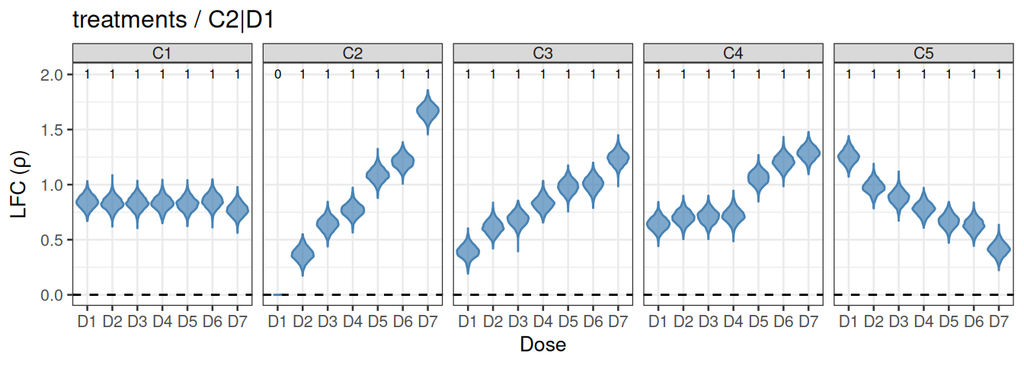

```r
u <- get_violins(x = o,
                 from_groups = get_groups(x = o)$group,
                 to_group = "C2|D1")
u$plot
```

# 9 Posterior predictive checks (PPCs)

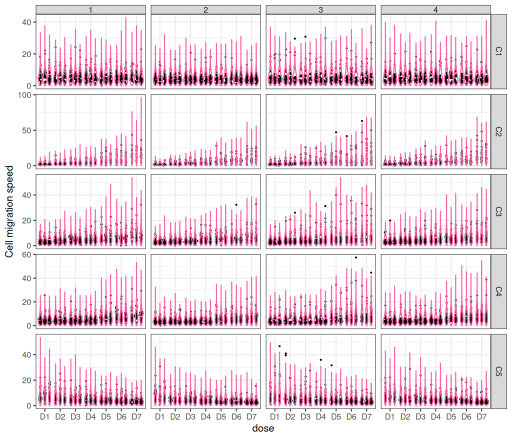

```r
g <- get_ppc_violins(x = o)
g
```

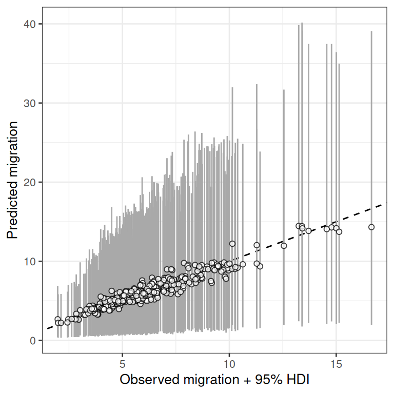

```r
g <- get_ppc_means(x = o)
g
```

# 10 `cellmig` can be used to simulate data

```r
control <- list(N_biorep = 3,
                N_techrep = 3,
                N_cell = 50,
                delta = c(0, -0.4, -0.2, -0.1,
                          0, 0.1, 0.2, 0.4),
                sigma_bio = 0.2,
                sigma_tech = 0.05,
                offset = 1,
                prior_alpha_p_M = 1.7,
                prior_alpha_p_SD = 0.5,
                prior_kappa_mu_M = 1.7,
                prior_kappa_mu_SD = 0.5,
                prior_kappa_sigma_M = 0,
                prior_kappa_sigma_SD = 0.3)

y_p <- gen_partial(control = control)
```

```
FALSE Chain 1:
FALSE Chain 1:  Elapsed Time: 0 seconds (Warm-up)
FALSE Chain 1:                0.002 seconds (Sampling)
FALSE Chain 1:                0.002 seconds (Total)
FALSE Chain 1:
```

We can show the newly simulated cell migration velocity (y-axis) for each cell (dot) at plate (color)

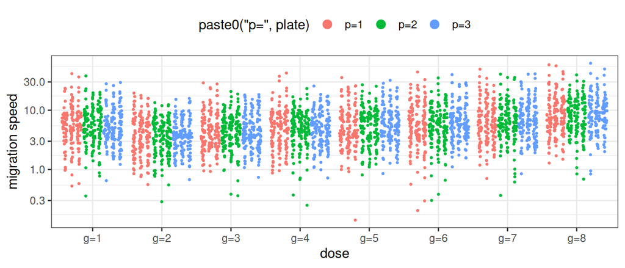

```r
ggplot(data = y_p$y)+
  geom_sina(aes(x = paste0("g=", group), col = paste0("p=", plate),
                y = v, group = well), size = 0.5)+
  theme_bw()+
  theme(legend.position = "top",
        strip.text.x = element_text(margin = margin(0.03,0,0.03,0, "cm")))+
  xlab(label = "dose")+
  ylab(label = "migration speed")+
  guides(color = guide_legend(override.aes = list(size = 3)))+
  scale_y_log10()
```

… or we can show the mean cell migration speed per well (dot) in each group (x-axis) and plate (color)

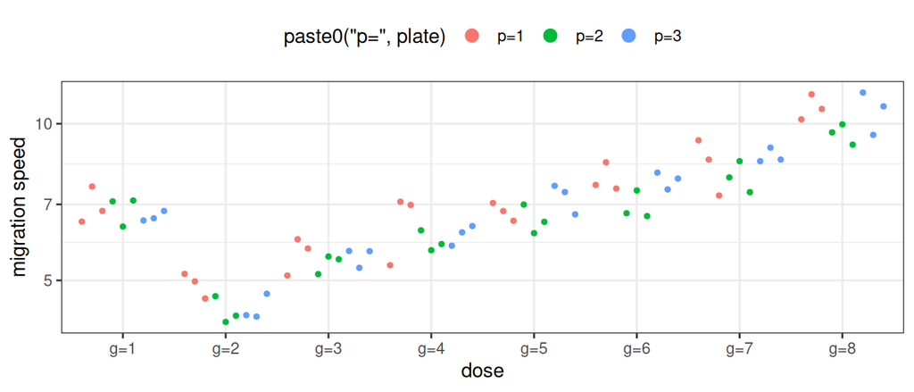

```r
ggplot(data = aggregate(v~well+group+plate, data = y_p$y, FUN = mean))+
  geom_sina(aes(x = paste0("g=", group), col = paste0("p=", plate),
                y = v, group = well), size = 1)+
  theme_bw()+
  theme(legend.position = "top",
        strip.text.x = element_text(margin = margin(0.03,0,0.03,0, "cm")))+
  xlab(label = "dose")+
  ylab(label = "migration speed")+
  guides(color = guide_legend(override.aes = list(size = 3)))+
  scale_y_log10()
```